# Integrating Python and Machine Learning — Building a Pitching Change Model for Baseball Games

## Simulated Game Prediction on Pitching Change

Because the number of correct substitution labels in the training set is very limited, we determined that evaluation metrics such as the confusion matrix and f1_score do not have much reference value. Therefore, I decided to generate pitching data for a simulated game and let the model determine the optimal timing for substitution, in order to assess the model’s effectiveness and rationality. It is worth noting that, as mentioned in the previous section, we set a threshold of 0.9 and developed substitution alert rules based on this threshold:  
1. In each game, after every plate appearance, if the score exceeds the 0.9 threshold, a “warning!!!” alert will be issued.  
2. In the same game (if any of the following conditions are met):  
2.1 A second occurrence of two consecutive plate appearances with “warning!!!”.  
2.2 Three consecutive plate appearances all showing “warning!!!”.  
2.3 Three “warning!!!” alerts in the last five plate appearances.  
2.4 A total of five plate appearances with “warning!!!” throughout the entire game.  
In such cases, a “change!!!” alert will be issued, indicating that a pitching change should be made.  
The following shows the code for simulated game prediction on pitching change:

```python
def predict(df_new, trained_model, scaler, threshold, output_name, use_weight = True):
    features = ['pitch_count', 'release_speed_diff', 'release_spin_rate_diff', 'reach_base', 'last_5']
    df_new = df_new.copy()

    # Keep the original velocity and spin rate differences
    df_new['original_release_speed_diff'] = df_new['release_speed_diff']
    df_new['original_release_spin_rate_diff'] = df_new['release_spin_rate_diff']

    df_new = df_new.dropna(subset = features)

    # Weight multiplier adjustment (based on pitch_count)
    if use_weight:
        weights = df_new['pitch_count'].apply(
            lambda pc: 0.2 if pc <= 10 else 0.4 if pc <= 20 else 0.6 if pc <= 30 else 0.8 if pc <= 40 else 1.0
        )
        df_new['release_speed_diff'] *= weights
        df_new['release_spin_rate_diff'] *= weights

    # Standardization
    X = df_new[features]
    X_scaled = scaler.transform(X)

    # Prediction and normalization into percentage
    decision_score = trained_model.decision_function(X_scaled)
    proba_like = (decision_score - decision_score.min()) / (decision_score.max() - decision_score.min())
    df_new['change_proba'] = ['{:.2f}%'.format(p * 100) for p in proba_like]
    df_new['warning'] = np.where(proba_like > threshold, "warning!!!", "")
    df_new['should_change'] = ""

    for gid, group in df_new.groupby('game_id'):
        group = group.reset_index()
        warnings = group['warning'].values
        change_flags = [""] * len(group)

        warning_count = 0
        double_warning_streaks = 0
        current_streak = 0
        second_double_found = False

        for i in range(len(group)):
            is_warning = warnings[i] == "warning!!!"
            if is_warning:
                current_streak += 1
                warning_count += 1
            else:
                current_streak = 0

            if current_streak == 2 and not second_double_found:
                double_warning_streaks += 1
                if double_warning_streaks == 2:
                    second_double_found = True

            cond0 = current_streak >= 3
            cond1 = second_double_found
            cond2 = np.sum(warnings[max(0, i - 4):i + 1] == "warning!!!") >= 3
            cond3 = warning_count >= 5

            if cond0 or cond1 or cond2 or cond3:
                change_flags[i] = "change!!!"

        df_new.loc[group['index'], 'should_change'] = change_flags

    # Restore original columns
    df_new['release_speed_diff'] = df_new['original_release_speed_diff']
    df_new['release_spin_rate_diff'] = df_new['original_release_spin_rate_diff']
    df_new.drop(columns=['original_release_speed_diff', 'original_release_spin_rate_diff'], inplace = True)

    df_new.to_csv(output_name, index = False, encoding='utf-8-sig')
    print(f"\nThe result has been saved as: {output_name}")
    return df_new
```

The following shows a partial excerpt of the test file containing the raw data for the simulated game:

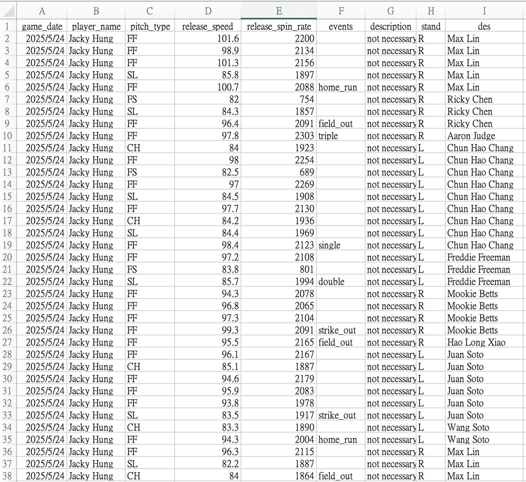

Figure6. Partial content of the test file with raw data from the simulated game

## Research Result

After model training and the generation of test data, the following shows the results of applying the pitching change alert system model to the simulated game:

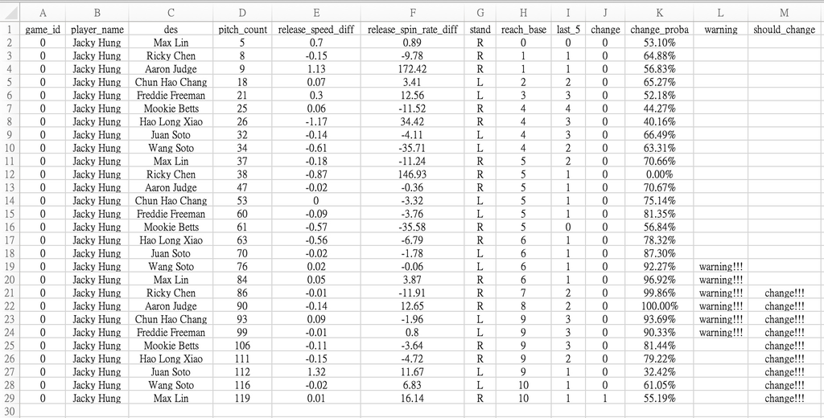

Figure7. Simulated game pitching change results